# My_Project

James Yonts

March 18, 2016

## R Markdown

I was interested in GDP per capita over time. I looked at which countries experienced the greatest increase in GDP per capita and which countries experienced the least growth, or even decline in GDP per capita. For each I looked at both the net change and the percent change. Percent change would likely be considered the better approach to compare changes among different countries. I also was interested in the GDP per capita by continent. I took a simplified approach and used the average of each countries GDP per capita (which is not truly equal to the continental GDP per capita.) Nonetheless, the results allow us to compare the growth over time of each continent generally.

The ten countries with the largest change in GDP are shown in Table 1.

Table 1

| Most Growth Countries | GDP Change | Most % Growth Countries | % GDP 2007 to 1952 |
| --- | --- | --- | --- |
| Singapore | 44828 | Equatorial Guinea | 3236 |
| Norway | 39262 | Taiwan | 2379 |
| Hong Kong China | 36671 | Korea Rep. | 2266 |
| Ireland | 35466 | Singapore | 2036 |
| Austria | 29989 | Botswana | 1477 |
| United States | 28961 | Hong Kong China | 1301 |
| Iceland | 28913 | China | 1238 |
| Japan | 28439 | Oman | 1221 |
| Netherlands | 27856 | Thailand | 984 |
| Taiwan | 27511 | Japan | 984 |

To me, the net change in GDP per capita did not have any surprises. The percent change in GDP was quite interesting though. I never heard much about Equatorial Guinea’s economic growth, after looking into it it turns out they discovered oil. It also served as a reminder of the economic miracle that occured in Japan after World War 2 - if the data was extended further back in history my guess would be that Japan would be even higher on the list.

The ten countries at the bottom of the change in GDP per capita list are shown in Table 2.

Table 2

| Lowest Growth Countries | GDP Change | Least % Growth Countries | % GDP Change 2007 to 1952 |
| --- | --- | --- | --- |
| Kuwait | -61075 | Congo Dem. Rep. | 36 |
| Haiti | -639 | Kuwait | 44 |
| Djibouti | -587 | Haiti | 65 |
| Congo Dem. Rep. | -503 | Central African Republic | 66 |
| Madagascar | -398 | Liberia | 72 |
| Central African Republic | -365 | Madagascar | 72 |
| Nicaragua | -363 | Djibouti | 78 |
| Somalia | -210 | Niger | 81 |
| Liberia | -161 | Somalia | 82 |
| Niger | -142 | Nicaragua | 88 |

The story here is Kuwait. I had never come across this before - GDP per capita was $108382.35 in the 1950’s. While being the largest net decrease, Kuwait still has a GDP per capita well above the global average at greater than $40000. I knew growth was slow in some of these nations but I would not have guessed that some nations had experienced decreases in GDP per capita over 55 years. That is so far removed from anything we experience in the United States.

Next, I plotted the average GDP per capita for each continent over time - log scale on the Y-axis.

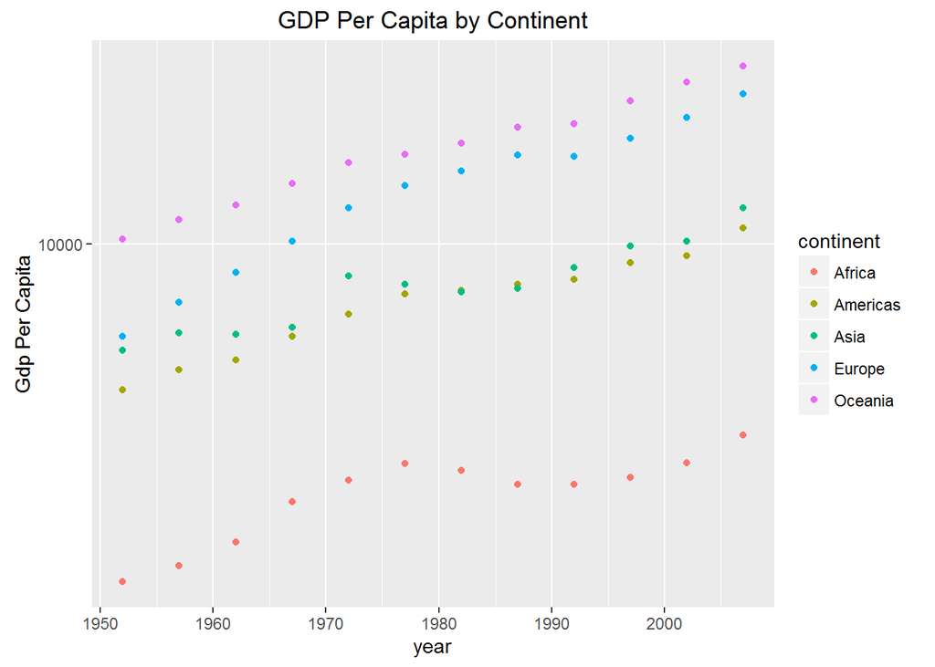

Europe’s continuous growth is fairly remarkable. It would be interesting to break down the Americas into Noth and South America. I would think North America’s growth would be more similar to Europe’s. Asia and Africa both had a decade (even longer for Africa) where the continent had little to no GDP growth per capita.